# timeseries

# 1 ARIMA

## 1.1 library

```r
library(data.table)
library(tidyverse)
library(forecast)
library(tseries)
```

## 1.2 데이터불러오기

임의로 예제 데이터 하나 생성

```r
example <- scan('C:\\Users\\uos\\Desktop\\tutoring-\\tutoring-\\data\\timeseries\\example.txt')
example.ts <- ts(example)
example.ts
```

```
## Time Series:
## Start = 1
## End = 108
## Frequency = 1
##   [1] 216 222 230 235 227 236 232 234 237 238 244 270 278 277 274 285 262 243
##  [19] 241 238 259 267 273 269 262 276 297 327 341 323 317 322 337 330 329 342
##  [37] 349 346 345 354 345 354 344 355 362 366 367 348 355 362 373 370 375 395
##  [55] 405 408 399 402 403 402 398 408 428 427 433 442 397 416 425 424 434 434
##  [73] 432 440 469 486 495 506 514 529 528 529 524 537 537 544 557 556 561 569
##  [91] 578 589 570 563 566 571 574 569 596 610 627 655 670 663 664 668 664 669
```

## 1.3 plot 그려보기 (PACF, ACF 확인)

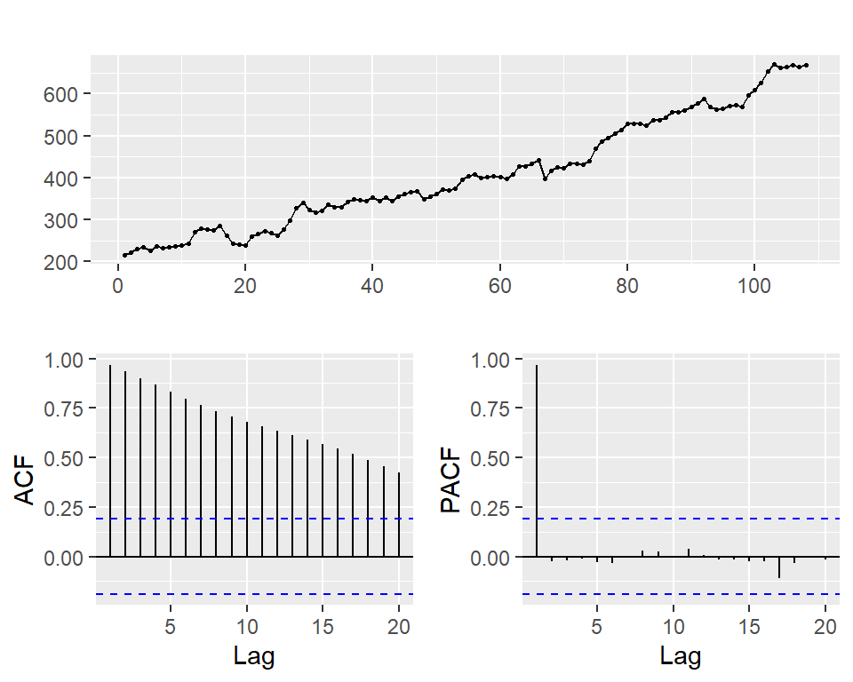

```r
ggtsdisplay(example.ts)
```

- plot을 봤을 때 정상성을 만족하지 못하는 것으로 보임.

## 1.4 정상성 확인

```r
adf.test(example.ts)
```

```
##
##  Augmented Dickey-Fuller Test
##
## data:  example.ts
## Dickey-Fuller = -1.8438, Lag order = 4, p-value = 0.6414
## alternative hypothesis: stationary
```

- ‘귀무가설: 비정상시계열’ 인 가설검정을 실시해 보았을 때 p-value가 0.05 보다 매우 높으므로 귀무가설 기각할 수 없음

```r
kpss.test(example.ts)
```

```
##
##  KPSS Test for Level Stationarity
##
## data:  example.ts
## KPSS Level = 2.1839, Truncation lag parameter = 4, p-value = 0.01
```

## 1.5 차분

```r
ndiffs(example.ts)
```

```
## [1] 1
```

- 1차 차분을 해야 정상성 만족

```r
example_d <- diff(example.ts)
example_d
```

```
## Time Series:
## Start = 2
## End = 108
## Frequency = 1
##   [1]   6   8   5  -8   9  -4   2   3   1   6  26   8  -1  -3  11 -23 -19  -2
##  [19]  -3  21   8   6  -4  -7  14  21  30  14 -18  -6   5  15  -7  -1  13   7
##  [37]  -3  -1   9  -9   9 -10  11   7   4   1 -19   7   7  11  -3   5  20  10
##  [55]   3  -9   3   1  -1  -4  10  20  -1   6   9 -45  19   9  -1  10   0  -2
##  [73]   8  29  17   9  11   8  15  -1   1  -5  13   0   7  13  -1   5   8   9
##  [91]  11 -19  -7   3   5   3  -5  27  14  17  28  15  -7   1   4  -4   5
```

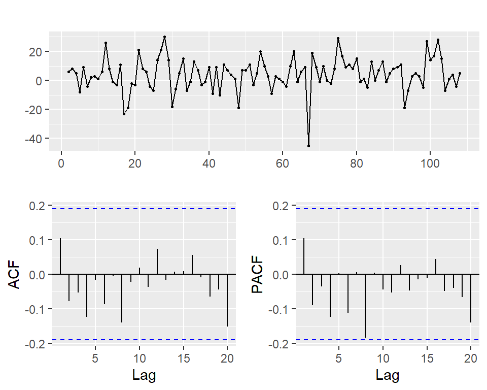

```r
ggtsdisplay(example_d)
```

- ACF, PACF 그림 모두 처음 lag 부터 절단점을 가짐. arima (0,1,0) 모델 활용 가능

```r
adf.test(example_d)
```

```
##
##  Augmented Dickey-Fuller Test
##
## data:  example_d
## Dickey-Fuller = -5.1366, Lag order = 4, p-value = 0.01
## alternative hypothesis: stationary
```

```r
kpss.test(example_d)
```

```
##
##  KPSS Test for Level Stationarity
##
## data:  example_d
## KPSS Level = 0.13912, Truncation lag parameter = 4, p-value = 0.1
```

- 위의 plot과 두 가설검정 결과 정상성을 만족하는 것으로 보인다.

## 1.6 분석

```r
auto.arima(example.ts, ic = 'bic')
```

```
## Series: example.ts
## ARIMA(0,1,0) with drift
##
## Coefficients:
##        drift
##       4.2336
## s.e.  1.0887
##
## sigma^2 estimated as 128:  log likelihood=-410.91
## AIC=825.82   AICc=825.94   BIC=831.17
```

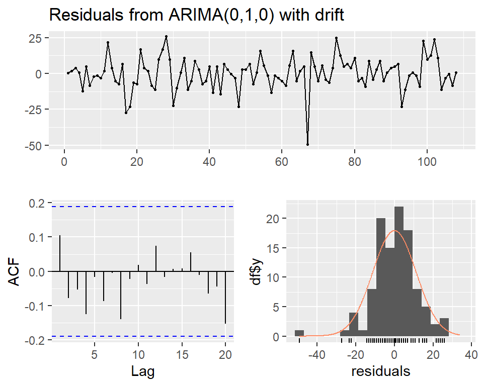

```
##
##  Ljung-Box test
##
## data:  Residuals from ARIMA(0,1,0) with drift
## Q* = 7.3436, df = 9, p-value = 0.6014
##
## Model df: 1.   Total lags used: 10
```

```r
fit <- Arima(example.ts, order = c(0, 1, 0), include.drift = T)
checkresiduals(fit)
```

- 잔차의 ACF 그림은 모든 LAG에서 0에 가까우므로 상관관계가 없다고 보여진다.
- 잔차의 히스토그램도 정규분포에 비슷한 모형을 띄는 것으로 보인다.
- Ljung-Box test: 잔차 독립성 검정 ’lag 10차까지 자기 상관관계가 존재하지 않는다.’는 귀무가설을 기각하지 못한다.

## 1.7 예측

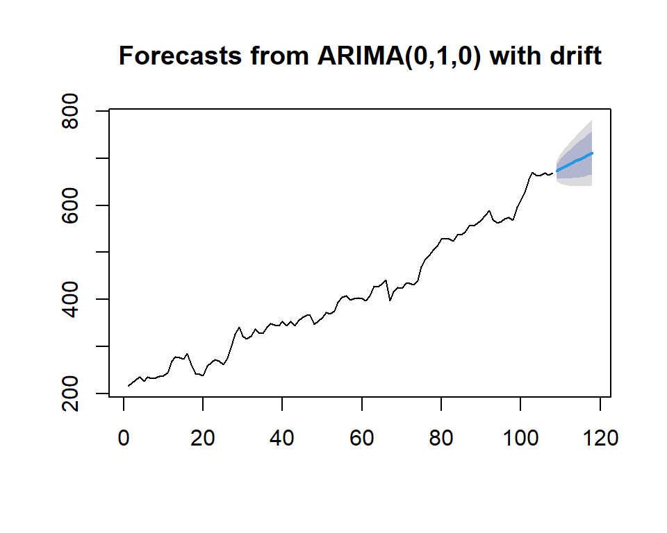

```r
plot(forecast(fit))
```

```r
summary(forecast(fit))
```

```
##
## Forecast method: ARIMA(0,1,0) with drift
##
## Model Information:
## Series: example.ts
## ARIMA(0,1,0) with drift
##
## Coefficients:
##        drift
##       4.2336
## s.e.  1.0887
##
## sigma^2 estimated as 128:  log likelihood=-410.91
## AIC=825.82   AICc=825.94   BIC=831.17
##
## Error measures:
##                       ME     RMSE      MAE        MPE     MAPE      MASE
## Training set 0.001960799 11.20896 8.236817 -0.1363965 2.225684 0.9002446
##                   ACF1
## Training set 0.1048095
##
## Forecasts:
##     Point Forecast    Lo 80    Hi 80    Lo 95    Hi 95
## 109       673.2336 658.7339 687.7334 651.0582 695.4091
## 110       677.4673 656.9616 697.9730 646.1065 708.8281
## 111       681.7009 656.5866 706.8152 643.2919 720.1099
## 112       685.9346 656.9351 714.9341 641.5837 730.2855
## 113       690.1682 657.7458 722.5906 640.5824 739.7540
## 114       694.4019 658.8849 729.9188 640.0833 748.7204
## 115       698.6355 660.2728 736.9982 639.9648 757.3062
## 116       702.8692 661.8577 743.8806 640.1475 765.5908
## 117       707.1028 663.6036 750.6020 640.5765 773.6291
## 118       711.3364 665.4842 757.1887 641.2115 781.4614
```

- 다음 시점의 값을 신뢰구간과 함께 예측한다.

# 2 SARIMA

## 2.1 데이터 불러오기

**데이터는 내장 데이터 AirPassengers 불러옴**

```r
data(AirPassengers)
AirPassengers
```

```
##      Jan Feb Mar Apr May Jun Jul Aug Sep Oct Nov Dec
## 1949 112 118 132 129 121 135 148 148 136 119 104 118
## 1950 115 126 141 135 125 149 170 170 158 133 114 140
## 1951 145 150 178 163 172 178 199 199 184 162 146 166
## 1952 171 180 193 181 183 218 230 242 209 191 172 194
## 1953 196 196 236 235 229 243 264 272 237 211 180 201
## 1954 204 188 235 227 234 264 302 293 259 229 203 229
## 1955 242 233 267 269 270 315 364 347 312 274 237 278
## 1956 284 277 317 313 318 374 413 405 355 306 271 306
## 1957 315 301 356 348 355 422 465 467 404 347 305 336
## 1958 340 318 362 348 363 435 491 505 404 359 310 337
## 1959 360 342 406 396 420 472 548 559 463 407 362 405
## 1960 417 391 419 461 472 535 622 606 508 461 390 432
```

## 2.2 분해시계열

### 2.2.1 추세요인, 계절요인 불규칙요인 확인

```r
AirPassengers.decompose = decompose(AirPassengers)
AirPassengers.decompose
```

```
## $x
##      Jan Feb Mar Apr May Jun Jul Aug Sep Oct Nov Dec
## 1949 112 118 132 129 121 135 148 148 136 119 104 118
## 1950 115 126 141 135 125 149 170 170 158 133 114 140
## 1951 145 150 178 163 172 178 199 199 184 162 146 166
## 1952 171 180 193 181 183 218 230 242 209 191 172 194
## 1953 196 196 236 235 229 243 264 272 237 211 180 201
## 1954 204 188 235 227 234 264 302 293 259 229 203 229
## 1955 242 233 267 269 270 315 364 347 312 274 237 278
## 1956 284 277 317 313 318 374 413 405 355 306 271 306
## 1957 315 301 356 348 355 422 465 467 404 347 305 336
## 1958 340 318 362 348 363 435 491 505 404 359 310 337
## 1959 360 342 406 396 420 472 548 559 463 407 362 405
## 1960 417 391 419 461 472 535 622 606 508 461 390 432
##
```

[output cut: 93 more lines]

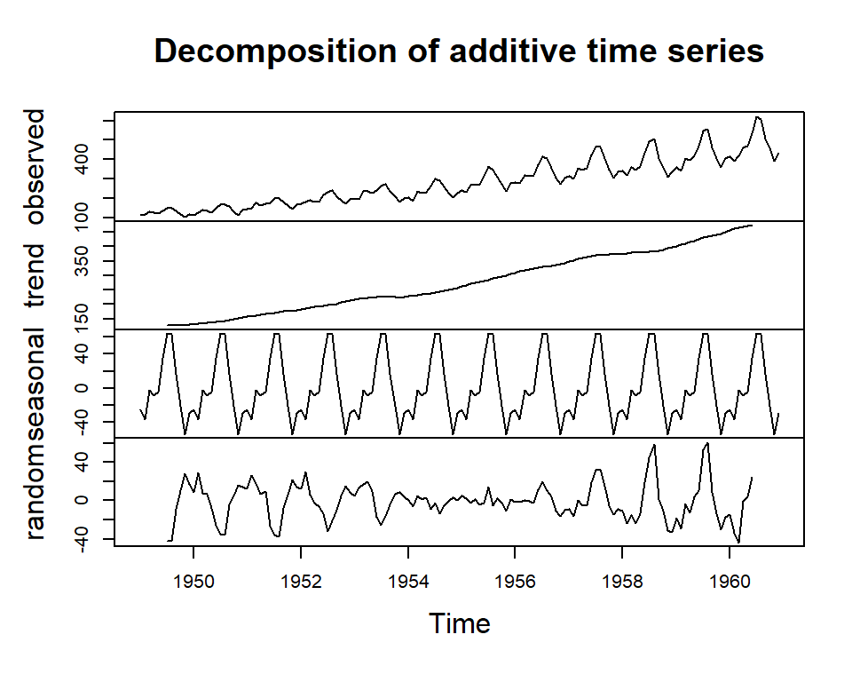

```r
plot(AirPassengers.decompose)
```

- 추세와 계절적 요인이 있는 것으로 보인다.

### 2.2.2 차분, 계절차분을 얼마나 해야 정상성을 만족하는지 확인

```r
ndiffs(AirPassengers)
```

```
## [1] 1
```

```r
nsdiffs(AirPassengers)
```

```
## [1] 1
```

- 1차차분과, 계절 차분을 실시하면 정상성을 만족할 것으로 보인다.

### 2.2.3 1차 차분, 계절 차분 실시하고 다시 PLOT 확인

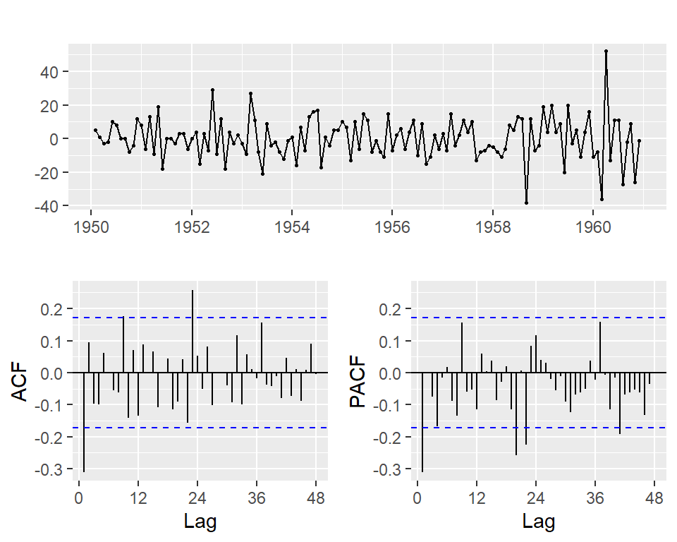

```r
AirPassengers_1 <- diff(AirPassengers)
AirPassengers_12 <- diff(AirPassengers_1,lag=12)
ggtsdisplay(AirPassengers_12,lag.max=48)
```

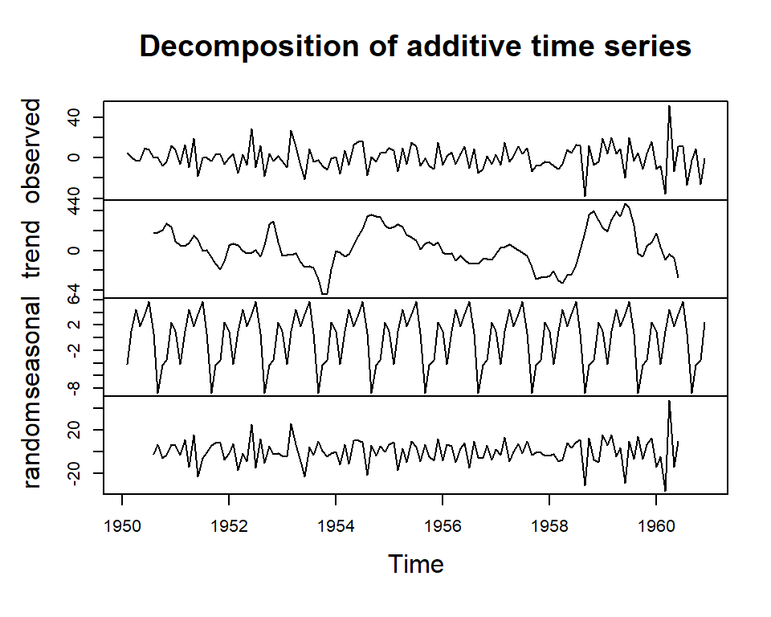

```r
plot(decompose(AirPassengers_12))
```

```r
adf.test(AirPassengers_12)
```

```
##
##  Augmented Dickey-Fuller Test
##
## data:  AirPassengers_12
## Dickey-Fuller = -5.0472, Lag order = 5, p-value = 0.01
## alternative hypothesis: stationary
```

```r
kpss.test(AirPassengers_12)
```

```
##
##  KPSS Test for Level Stationarity
##
## data:  AirPassengers_12
## KPSS Level = 0.054287, Truncation lag parameter = 4, p-value = 0.1
```

## 2.3 모델링

```r
auto.arima(AirPassengers,d=1,D=1,ic = 'bic')
```

```
## Series: AirPassengers
## ARIMA(1,1,0)(0,1,0)[12]
##
## Coefficients:
##           ar1
##       -0.3076
## s.e.   0.0828
##
## sigma^2 estimated as 138.1:  log likelihood=-508.2
## AIC=1020.39   AICc=1020.49   BIC=1026.14
```

- R에서는 auto.arima 함수를 통해 데이터에 가장 적합한 모델을 찾아줄 수 있다.
- 여기서는 $ARIMA(1,1,0)(0,1,0)_{12}$ 이 가장 좋은 모델로 선정되었다.

```r
fit1 = Arima(AirPassengers, order=c(0,1,1), seasonal=list(order=c(0,1,0),period=12))
fit1
```

```
## Series: AirPassengers
## ARIMA(0,1,1)(0,1,0)[12]
##
## Coefficients:
##           ma1
##       -0.3184
## s.e.   0.0877
##
## sigma^2 estimated as 138.3:  log likelihood=-508.32
## AIC=1020.64   AICc=1020.73   BIC=1026.39
```

```r
fit2 = Arima(AirPassengers, order=c(1,1,1), seasonal=list(order=c(0,1,0),period=12))
fit2
```

```
## Series: AirPassengers
## ARIMA(1,1,1)(0,1,0)[12]
##
## Coefficients:
##           ar1      ma1
##       -0.3009  -0.0073
## s.e.   0.3835   0.4133
##
## sigma^2 estimated as 139.1:  log likelihood=-508.2
## AIC=1022.39   AICc=1022.58   BIC=1031.02
```

```r
fit3 = Arima(AirPassengers, order=c(1,1,0), seasonal=list(order=c(0,1,0),period=12))
fit3
```

```
## Series: AirPassengers
## ARIMA(1,1,0)(0,1,0)[12]
##
## Coefficients:
##           ar1
##       -0.3076
## s.e.   0.0828
##
## sigma^2 estimated as 138.1:  log likelihood=-508.2
## AIC=1020.39   AICc=1020.49   BIC=1026.14
```

- 원래 예상한 모델들을 다 돌려봐니 모델 적합도인 AIC와 BIC가 거의 차이가 나지 않는 모습이어서 어느 모델을 채택해도 비슷한 결과가 나올 것으로 예상된다.

```r
confint(fit3)
```

```
##          2.5 %     97.5 %
## ar1 -0.4698484 -0.1453851
```

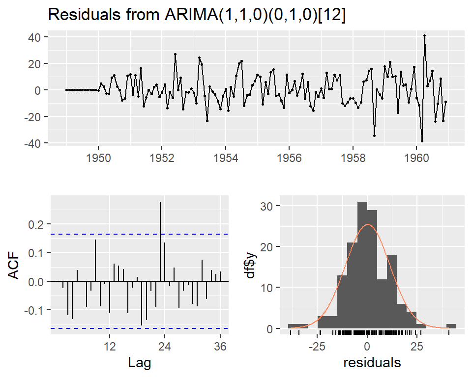

```
##
##  Ljung-Box test
##
## data:  Residuals from ARIMA(1,1,0)(0,1,0)[12]
## Q* = 41.392, df = 23, p-value = 0.01068
##
## Model df: 1.   Total lags used: 24
```

```r
checkresiduals(fit3)
```

- 가장 좋은 모델로 선정된 $ARIMA(1,1,0)(0,1,0)_{12}$ 모델을 확인해보니 잔차의 히스토그램도 정규분포와 유사하게 나오는 것 같다.
- Ljung-Box test 에서도 귀무가설을 기각하는 p-value가 나와서, ’lag 24차까지 자기 상관관계가 존재하지 않는다.’는 귀무가설을 기각하므로 잔차의 자기상관이 있다는 뜻이 된다. 따라서, 가정을 완벽하게 만족하는 모델이라고 볼 수는 없는 듯 하다.

```r
fit3_1 <- Arima(AirPassengers,order=c(0,1,1), seasonal=list(order=c(0,1,1), period=12),
                lambda=0)
fit3_1
```

```
## Series: AirPassengers
## ARIMA(0,1,1)(0,1,1)[12]
## Box Cox transformation: lambda= 0
##
## Coefficients:
##           ma1     sma1
##       -0.4018  -0.5569
## s.e.   0.0896   0.0731
##
## sigma^2 estimated as 0.001371:  log likelihood=244.7
## AIC=-483.4   AICc=-483.21   BIC=-474.77
```

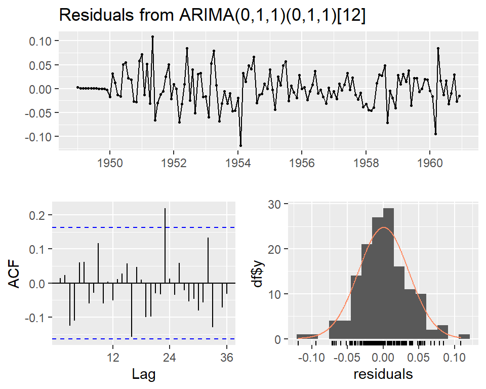

```
##
##  Ljung-Box test
##
## data:  Residuals from ARIMA(0,1,1)(0,1,1)[12]
## Q* = 26.446, df = 22, p-value = 0.233
##
## Model df: 2.   Total lags used: 24
```

```r
checkresiduals(fit3_1)
```

```r
forecast(fit3_1,h=12,level=95)
```

```
##          Point Forecast    Lo 95    Hi 95
## Jan 1961       450.4224 418.8895 484.3289
## Feb 1961       425.7172 391.1938 463.2874
## Mar 1961       479.0068 435.5677 526.7781
## Apr 1961       492.4045 443.5416 546.6503
## May 1961       509.0550 454.5866 570.0497
## Jun 1961       583.3449 516.7552 658.5155
## Jul 1961       670.0108 589.0693 762.0740
## Aug 1961       667.0776 582.3280 764.1613
## Sep 1961       558.1894 483.9871 643.7679
## Oct 1961       497.2078 428.3358 577.1537
## Nov 1961       429.8720 368.0412 502.0903
## Dec 1961       477.2426 406.1725 560.7482
```

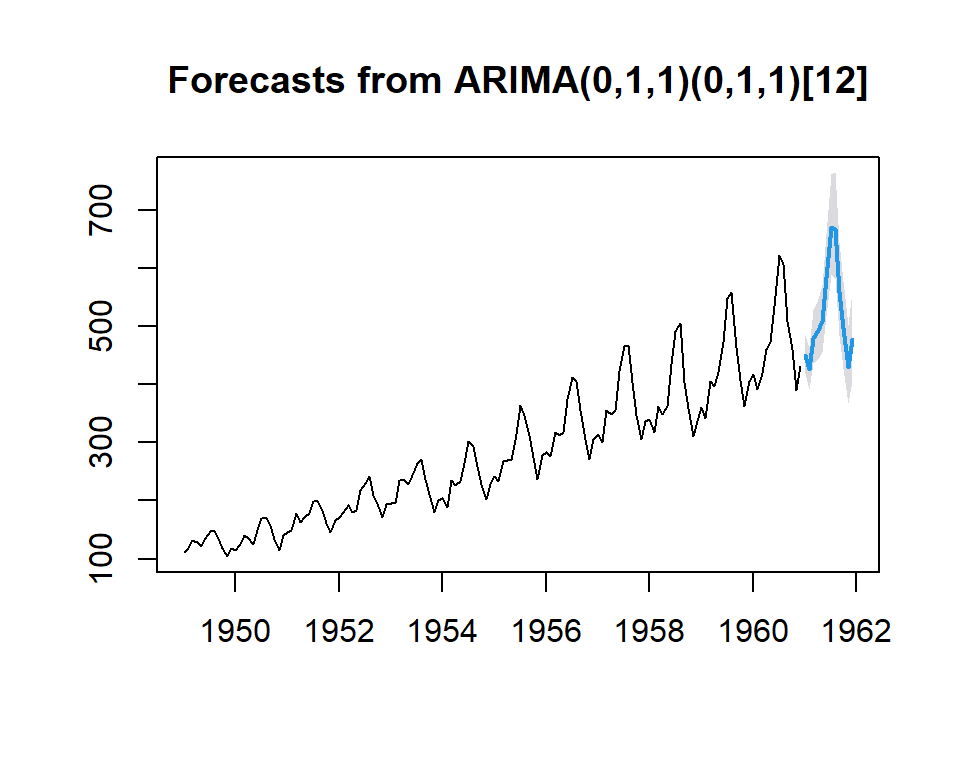

```r
plot(forecast(fit3_1,h=12,level=95))
```

```r
summary(forecast(fit3_1,h=12,level=95))
```

```
##
## Forecast method: ARIMA(0,1,1)(0,1,1)[12]
##
## Model Information:
## Series: AirPassengers
## ARIMA(0,1,1)(0,1,1)[12]
## Box Cox transformation: lambda= 0
##
## Coefficients:
##           ma1     sma1
##       -0.4018  -0.5569
## s.e.   0.0896   0.0731
##
## sigma^2 estimated as 0.001371:  log likelihood=244.7
## AIC=-483.4   AICc=-483.21   BIC=-474.77
##
## Error measures:
##                      ME     RMSE      MAE          MPE     MAPE     MASE
## Training set 0.05140418 10.15504 7.357553 -0.004079016 2.623636 0.229706
##                     ACF1
## Training set -0.03689673
##
## Forecasts:
##          Point Forecast    Lo 95    Hi 95
## Jan 1961       450.4224 418.8895 484.3289
## Feb 1961       425.7172 391.1938 463.2874
## Mar 1961       479.0068 435.5677 526.7781
## Apr 1961       492.4045 443.5416 546.6503
## May 1961       509.0550 454.5866 570.0497
## Jun 1961       583.3449 516.7552 658.5155
## Jul 1961       670.0108 589.0693 762.0740
## Aug 1961       667.0776 582.3280 764.1613
## Sep 1961       558.1894 483.9871 643.7679
## Oct 1961       497.2078 428.3358 577.1537
## Nov 1961       429.8720 368.0412 502.0903
## Dec 1961       477.2426 406.1725 560.7482
```

# 3 Timeseries regression

## 3.1 데이터 불러오기

**데이터 출처: 데이콘 전력사용량 예측 AI 경진대회 https://dacon.io/competitions/official/235736/overview/description**

** 데이콘 전력사용량 예측 데이터에서 60개의 관측소가 있는데 1개의 관측소를 가지고 시계열 분석을 해보았았다.**

```r
energy = fread('C:\\Users\\uos\\Desktop\\dacon\\data\\energy\\train.csv')
energy = energy %>% filter(num==1)
energy_test = fread('C:\\Users\\uos\\Desktop\\dacon\\data\\energy\\test.csv')
energy_test = energy_test %>% filter(num==1)
energy %>% head(10)
```

```
##     num     date_time 전력사용량(kWh) 기온(°C) 풍속(m/s) 습도(%) 강수량(mm)
##  1:   1 2020-06-01 00        8179.056      17.6       2.5      92        0.8
##  2:   1 2020-06-01 01        8135.640      17.7       2.9      91        0.3
##  3:   1 2020-06-01 02        8107.128      17.5       3.2      91        0.0
##  4:   1 2020-06-01 03        8048.808      17.1       3.2      91        0.0
##  5:   1 2020-06-01 04        8043.624      17.0       3.3      92        0.0
##  6:   1 2020-06-01 05        8010.576      16.9       3.4      93        0.0
##  7:   1 2020-06-01 06        7978.176      16.7       3.4      90        0.1
##  8:   1 2020-06-01 07        8019.000      16.9       2.3      86        0.0
##  9:   1 2020-06-01 08        8020.944      17.8       3.3      80        0.0
## 10:   1 2020-06-01 09        8083.152      19.3       2.1      73        0.0
##     일조(hr) 비전기냉방설비운영 태양광보유
##  1:      0.0                  0          0
##  2:      0.0                  0          0
##  3:      0.0                  0          0
##  4:      0.0                  0          0
##  5:      0.0                  0          0
##  6:      0.0                  0          0
##  7:      0.0                  0          0
##  8:      0.1                  0          0
##  9:      0.3                  0          0
## 10:      0.7                  0          0
```

```r
energy %>% str()
```

```
## Classes 'data.table' and 'data.frame':   2040 obs. of  10 variables:
##  $ num               : int  1 1 1 1 1 1 1 1 1 1 ...
##  $ date_time         : chr  "2020-06-01 00" "2020-06-01 01" "2020-06-01 02" "2020-06-01 03" ...
##  $ 전력사용량(kWh)   : num  8179 8136 8107 8049 8044 ...
##  $ 기온(°C)         : num  17.6 17.7 17.5 17.1 17 16.9 16.7 16.9 17.8 19.3 ...
##  $ 풍속(m/s)         : num  2.5 2.9 3.2 3.2 3.3 3.4 3.4 2.3 3.3 2.1 ...
##  $ 습도(%)           : num  92 91 91 91 92 93 90 86 80 73 ...
##  $ 강수량(mm)        : num  0.8 0.3 0 0 0 0 0.1 0 0 0 ...
##  $ 일조(hr)          : num  0 0 0 0 0 0 0 0.1 0.3 0.7 ...
##  $ 비전기냉방설비운영: num  0 0 0 0 0 0 0 0 0 0 ...
##  $ 태양광보유        : num  0 0 0 0 0 0 0 0 0 0 ...
##  - attr(*, ".internal.selfref")=<externalptr>
```

```r
energy %>% glimpse()
```

```
## Rows: 2,040
## Columns: 10
## $ num                <int> 1, 1, 1, 1, 1, 1, 1, 1, 1, 1, 1, 1, 1, 1, 1, 1, 1, ~
## $ date_time          <chr> "2020-06-01 00", "2020-06-01 01", "2020-06-01 02", ~
## $ `전력사용량(kWh)`  <dbl> 8179.056, 8135.640, 8107.128, 8048.808, 8043.624, 8010.5~
## $ `기온(°C)`         <dbl> 17.6, 17.7, 17.5, 17.1, 17.0, 16.9, 16.7, 16.9, 17.8,~
## $ `풍속(m/s)`        <dbl> 2.5, 2.9, 3.2, 3.2, 3.3, 3.4, 3.4, 2.3, 3.3, 2.1, 3.4~
## $ `습도(%)`          <dbl> 92, 91, 91, 91, 92, 93, 90, 86, 80, 73, 62, 52, 49, 4~
## $ `강수량(mm)`       <dbl> 0.8, 0.3, 0.0, 0.0, 0.0, 0.0, 0.1, 0.0, 0.0, 0.0, 0.0,~
## $ `일조(hr)`         <dbl> 0.0, 0.0, 0.0, 0.0, 0.0, 0.0, 0.0, 0.1, 0.3, 0.7, 1.0~
## $ 비전기냉방설비운영 <dbl> 0, 0, 0, 0, 0, 0, 0, 0, 0, 0, 0, 0, 0, 0, 0, 0, 0, 0, 0, 0, ~
## $ 태양광보유         <dbl> 0, 0, 0, 0, 0, 0, 0, 0, 0, 0, 0, 0, 0, 0, 0, 0, 0, 0, 0,~
```

- 먼저, 기본적으로 데이터의 구조를 살펴보았다.

```r
energy = energy %>%
  mutate (hour = as.numeric(substr(date_time,12,13)),
          date = as.Date(substr(date_time,1,10),format='%Y-%m-%d')) %>%
  select(-c(date_time))

colnames(energy) = c('num','kwh','temp','wind','humidity','rain','sun','non_electric','sunlight','hour','date')
energy %>% glimpse()
```

```
## Rows: 2,040
## Columns: 11
## $ num          <int> 1, 1, 1, 1, 1, 1, 1, 1, 1, 1, 1, 1, 1, 1, 1, 1, 1, 1, 1, ~
## $ kwh          <dbl> 8179.056, 8135.640, 8107.128, 8048.808, 8043.624, 8010.57~
## $ temp         <dbl> 17.6, 17.7, 17.5, 17.1, 17.0, 16.9, 16.7, 16.9, 17.8, 19.~
## $ wind         <dbl> 2.5, 2.9, 3.2, 3.2, 3.3, 3.4, 3.4, 2.3, 3.3, 2.1, 3.4, 3.~
## $ humidity     <dbl> 92, 91, 91, 91, 92, 93, 90, 86, 80, 73, 62, 52, 49, 42, 3~
## $ rain         <dbl> 0.8, 0.3, 0.0, 0.0, 0.0, 0.0, 0.1, 0.0, 0.0, 0.0, 0.0, 0.~
## $ sun          <dbl> 0.0, 0.0, 0.0, 0.0, 0.0, 0.0, 0.0, 0.1, 0.3, 0.7, 1.0, 1.~
## $ non_electric <dbl> 0, 0, 0, 0, 0, 0, 0, 0, 0, 0, 0, 0, 0, 0, 0, 0, 0, 0, 0, ~
## $ sunlight     <dbl> 0, 0, 0, 0, 0, 0, 0, 0, 0, 0, 0, 0, 0, 0, 0, 0, 0, 0, 0, ~
## $ hour         <dbl> 0, 1, 2, 3, 4, 5, 6, 7, 8, 9, 10, 11, 12, 13, 14, 15, 16,~
## $ date         <date> 2020-06-01, 2020-06-01, 2020-06-01, 2020-06-01, 2020-06-~
```

- 데이터에서 날짜 데이터에서 시간만 따로 떼어내서 새로운 변수로 만들어주고 R에서 사용하기 편하게 영어변수로 변경해주었다.

## 3.2 regression 잔차 확인

```r
attach(energy)
energy.ts = ts(kwh)
fit = lm(energy.ts ~ temp + wind + humidity + rain + sun + hour)
fit
```

```
##
## Call:
## lm(formula = energy.ts ~ temp + wind + humidity + rain + sun +
##     hour)
##
## Coefficients:
## (Intercept)         temp         wind     humidity         rain          sun
##   7414.1458      35.5993      -2.0390       3.3040      -0.8125     -54.9422
##        hour
##      1.5130
```

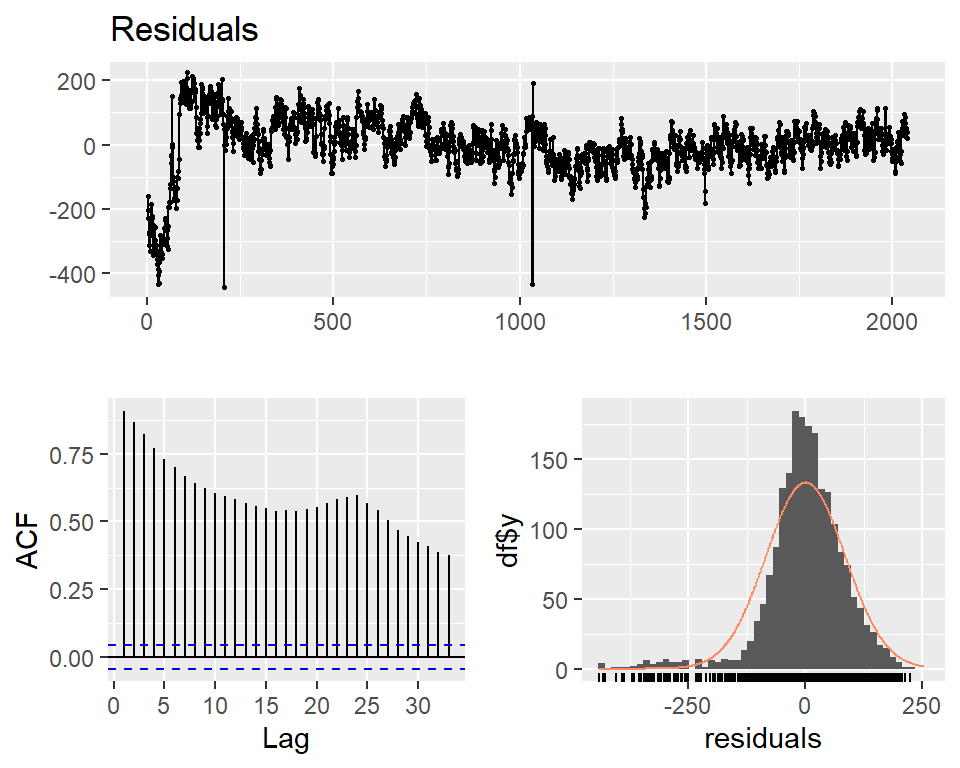

```
##
##  Breusch-Godfrey test for serial correlation of order up to 10
##
## data:  Residuals
## LM test = 1709.8, df = 10, p-value < 2.2e-16
```

```r
checkresiduals(fit)
```

- factor 변수로 고정되어 있는 변수를 제외한 나머지를 linear regression하여 잔차를 체크해보고 정상성을 만족하는지 보았다. 정상성을 만족하지 못하는 것으로 보여진다.

```r
ndiffs(fit$residuals)
```

```
## [1] 1
```

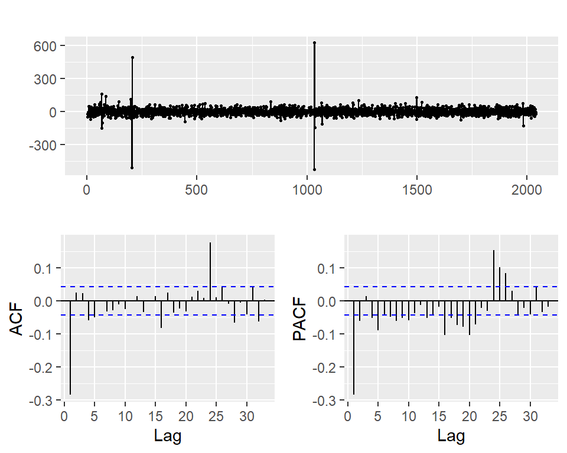

```r
ggtsdisplay(diff(fit$residuals))
```

```r
auto.arima(fit$residuals,ic='bic')
```

```
## Series: fit$residuals
## ARIMA(2,1,1)
##
## Coefficients:
##          ar1     ar2      ma1
##       0.6131  0.1924  -0.9488
## s.e.  0.0255  0.0235   0.0121
##
## sigma^2 estimated as 1167:  log likelihood=-10091.85
## AIC=20191.69   AICc=20191.71   BIC=20214.17
```

- ndiffs 함수로 1차 차분하면 정상성을 만족한다는 것을 확인하고 1차 차분을 진행하였다.
- 차분한 데이터로 plot과 ACF,PACF 그림을 보았을때, ARIMA(2,1,0), ARIMA(0,1,1), ARIMA(2,1,1) 모델을 후보군으로 생각 할 수 있었다.
- auto.arima 함수를 이용하여 확인하여 보니 ARIMA(2,1,1) 모델이 가장 적합한 모델로 선정되었다.

## 3.3 데이터 모델링

```r
energy_x = energy %>% select(-c(kwh,date,num,sunlight,non_electric))
f1 = Arima(energy.ts, order = c(2, 1, 1), xreg = as.matrix(energy_x))
f1
```

```
## Series: energy.ts
## Regression with ARIMA(2,1,1) errors
##
## Coefficients:
##          ar1     ar2      ma1     temp    wind  humidity     rain       sun
##       0.6554  0.1765  -0.9491  20.6889  2.1245    1.4824  -0.1998  -14.0838
## s.e.  0.0264  0.0236   0.0123   1.4947  1.0007    0.3138   0.3472    4.2930
##         hour
##       0.4912
## s.e.  0.1574
##
## sigma^2 estimated as 1050:  log likelihood=-9980.8
## AIC=19981.6   AICc=19981.7   BIC=20037.8
```

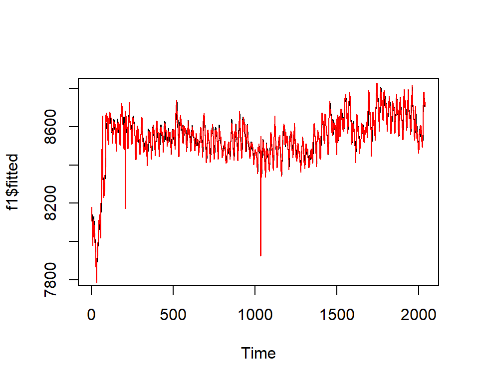

```r
plot(f1$fitted)
lines(energy.ts,col='red')
```

```r
detach(energy)
```

- ARIMA(2,1,1) 에 Regression을 더한 모델을 적합해보았고 plot을 그려 예측치와 실제값을 비교해보았다.

## 3.4 예측

```r
energy_test%>%glimpse()
```

```
## Rows: 168
## Columns: 9
## $ num                 <int> 1, 1, 1, 1, 1, 1, 1, 1, 1, 1, 1, 1, 1, 1, 1, 1, 1,~
## $ date_time           <chr> "2020-08-25 00", "2020-08-25 01", "2020-08-25 02",~
## $ `기온(°C)`          <dbl> 27.8, NA, NA, 27.3, NA, NA, 26.1, NA, NA, 28.8, NA, ~
## $ `풍속(m/s)`         <dbl> 1.5, NA, NA, 1.1, NA, NA, 1.3, NA, NA, 1.2, NA, NA, ~
## $ `습도(%)`           <dbl> 74, NA, NA, 78, NA, NA, 83, NA, NA, 77, NA, NA, 57, ~
## $ `강수량(mm, 6시간)` <dbl> 0, NA, NA, NA, NA, NA, 0, NA, NA, NA, NA, NA, 0, NA, NA~
## $ `일조(hr, 3시간)`   <dbl> 0.0, NA, NA, 0.0, NA, NA, 0.0, NA, NA, 1.1, NA, NA, 3.~
## $ 비전기냉방설비운영  <dbl> NA, NA, NA, NA, NA, NA, NA, NA, NA, NA, NA, NA, NA, NA, NA,~
## $ 태양광보유          <dbl> NA, NA, NA, NA, NA, NA, NA, NA, NA, NA, NA, NA, NA, NA,~
```

```r
energy_test%>%head(10)
```

```
##     num     date_time 기온(°C) 풍속(m/s) 습도(%) 강수량(mm, 6시간)
##  1:   1 2020-08-25 00      27.8       1.5      74                 0
##  2:   1 2020-08-25 01        NA        NA      NA                NA
##  3:   1 2020-08-25 02        NA        NA      NA                NA
##  4:   1 2020-08-25 03      27.3       1.1      78                NA
##  5:   1 2020-08-25 04        NA        NA      NA                NA
##  6:   1 2020-08-25 05        NA        NA      NA                NA
##  7:   1 2020-08-25 06      26.1       1.3      83                 0
##  8:   1 2020-08-25 07        NA        NA      NA                NA
##  9:   1 2020-08-25 08        NA        NA      NA                NA
## 10:   1 2020-08-25 09      28.8       1.2      77                NA
##     일조(hr, 3시간) 비전기냉방설비운영 태양광보유
##  1:             0.0                 NA         NA
##  2:              NA                 NA         NA
##  3:              NA                 NA         NA
##  4:             0.0                 NA         NA
##  5:              NA                 NA         NA
##  6:              NA                 NA         NA
##  7:             0.0                 NA         NA
##  8:              NA                 NA         NA
##  9:              NA                 NA         NA
## 10:             1.1                 NA         NA
```

```r
energy_test%>%is.na()%>%colSums()
```

```
##                num          date_time          기온(°C)          풍속(m/s)
##                  0                  0                112                112
##            습도(%)  강수량(mm, 6시간)    일조(hr, 3시간) 비전기냉방설비운영
##                112                140                112                168
##         태양광보유
##                168
```

- test set을 확인해보니 결측치가 많은 것이 눈에 띄었다.

```r
energy_test = energy_test %>%
  mutate (hour = as.numeric(substr(date_time,12,13)),
          date = as.Date(substr(date_time,1,10),format='%Y-%m-%d')) %>%
  select(-c(date_time))

colnames(energy_test) = c('num','temp','wind','humidity','rain','sun','non_electric','sunlight','hour','date')

energy_test$non_electric = ifelse(is.na(energy_test$non_electric),0,energy_test$non_electric)
energy_test$sunlight = ifelse(is.na(energy_test$sunlight),0,energy_test$sunlight)

energy_test = zoo::na.locf(energy_test)

energy_test %>% is.na() %>% colSums()
```

```
##          num         temp         wind     humidity         rain          sun
##            0            0            0            0            0            0
## non_electric     sunlight         hour         date
##            0            0            0            0
```

```r
energy_test %>% head(10)
```

```
##     num temp wind humidity rain sun non_electric sunlight hour       date
##  1:   1 27.8  1.5       74    0 0.0            0        0    0 2020-08-25
##  2:   1 27.8  1.5       74    0 0.0            0        0    1 2020-08-25
##  3:   1 27.8  1.5       74    0 0.0            0        0    2 2020-08-25
##  4:   1 27.3  1.1       78    0 0.0            0        0    3 2020-08-25
##  5:   1 27.3  1.1       78    0 0.0            0        0    4 2020-08-25
##  6:   1 27.3  1.1       78    0 0.0            0        0    5 2020-08-25
##  7:   1 26.1  1.3       83    0 0.0            0        0    6 2020-08-25
##  8:   1 26.1  1.3       83    0 0.0            0        0    7 2020-08-25
##  9:   1 26.1  1.3       83    0 0.0            0        0    8 2020-08-25
## 10:   1 28.8  1.2       77    0 1.1            0        0    9 2020-08-25
```

```r
energy_test_x = energy_test[,-c('date','num','sunlight','non_electric')]
forecast(f1,xreg = as.matrix(energy_test_x),level=95)
```

```
##      Point Forecast    Lo 95    Hi 95
## 2041       8687.434 8623.932 8750.937
## 2042       8684.635 8606.890 8762.380
## 2043       8682.957 8593.704 8772.209
## 2044       8676.180 8578.424 8773.936
## 2045       8674.976 8570.414 8779.537
## 2046       8674.002 8563.868 8784.137
## 2047       8656.245 8541.429 8771.061
## 2048       8655.652 8536.827 8774.478
## 2049       8655.211 8532.893 8777.529
## 2050       8686.160 8560.756 8811.565
## 2051       8685.961 8557.791 8814.131
## 2052       8685.858 8555.182 8816.534
## 2053       8714.791 8581.820 8847.762
## 2054       8714.842 8579.750 8849.935
```

[output cut: 154 more lines]

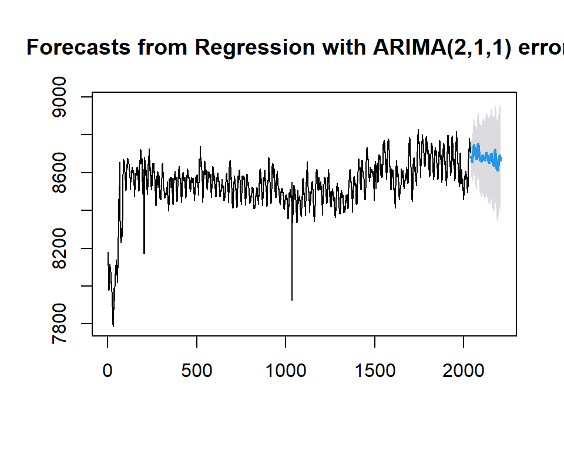

```r
plot(forecast(f1,xreg = as.matrix(energy_test_x),level =95))
```

- 이를 토대로 앞의 모델로 95% 신뢰구간과 함께 test set을 예측해보았다.

```r
accuracy(f1)
```

```
##                     ME     RMSE      MAE         MPE      MAPE     MASE
## Training set 0.5622977 32.32027 20.08983 0.005314548 0.2356848 0.959981
##                     ACF1
## Training set 0.004673146
```